# 🧠💓 Stroke Analysis and Data Visualization

## 📌 About This Project

This notebook is designed to **analyze stroke risk factors** and **gain insights through data analysis techniques**. Stroke is a serious health issue worldwide, but early detection and preventive measures can significantly reduce the risk.

## 📊 Techniques Used

- **Data Cleaning & Preprocessing** 🛠️
- **Exploratory Data Analysis (EDA)** 🔍
- **Data Visualization (Histograms, Box Plots, Correlation Matrices, etc.)** 📈
- **Predictive Modeling with Machine Learning (Optional)** 🤖

By the end of this analysis, we aim to develop a **clearer understanding of stroke risk factors** and derive **data-driven insights**. 🚀

📝 **Let's get started!**

```python
import pandas as pd
import numpy as np
import matplotlib.pyplot as plt
import seaborn as sns

import warnings
warnings.filterwarnings('ignore')
```

```python
df=pd.read_csv("healthcare-dataset-stroke-data.csv")
df
```

|  | id | gender | age | hypertension | heart_disease | ever_married | work_type | Residence_type | avg_glucose_level | bmi | smoking_status | stroke |
| --- | --- | --- | --- | --- | --- | --- | --- | --- | --- | --- | --- | --- |
| 0 | 9046 | Male | 67.0 | 0 | 1 | Yes | Private | Urban | 228.69 | 36.6 | formerly smoked | 1 |
| 1 | 51676 | Female | 61.0 | 0 | 0 | Yes | Self-employed | Rural | 202.21 | NaN | never smoked | 1 |
| 2 | 31112 | Male | 80.0 | 0 | 1 | Yes | Private | Rural | 105.92 | 32.5 | never smoked | 1 |
| 3 | 60182 | Female | 49.0 | 0 | 0 | Yes | Private | Urban | 171.23 | 34.4 | smokes | 1 |
| 4 | 1665 | Female | 79.0 | 1 | 0 | Yes | Self-employed | Rural | 174.12 | 24.0 | never smoked | 1 |
| ... | ... | ... | ... | ... | ... | ... | ... | ... | ... | ... | ... | ... |
| 5105 | 18234 | Female | 80.0 | 1 | 0 | Yes | Private | Urban | 83.75 | NaN | never smoked | 0 |
| 5106 | 44873 | Female | 81.0 | 0 | 0 | Yes | Self-employed | Urban | 125.20 | 40.0 | never smoked | 0 |
| 5107 | 19723 | Female | 35.0 | 0 | 0 | Yes | Self-employed | Rural | 82.99 | 30.6 | never smoked | 0 |
| 5108 | 37544 | Male | 51.0 | 0 | 0 | Yes | Private | Rural | 166.29 | 25.6 | formerly smoked | 0 |
| 5109 | 44679 | Female | 44.0 | 0 | 0 | Yes | Govt_job | Urban | 85.28 | 26.2 | Unknown | 0 |

5110 rows × 12 columns

```python
df1=df.copy()
```

✲ There are 5110 rows and 12 columns.

•id: Unique identifier for each individual.

•gender: Gender of the individual (Male/Female).

•age: Age of the individual in years.

•hypertension: Whether the individual has hypertension (1: Yes, 0: No).

•heart_disease: Whether the individual has heart disease (1: Yes, 0: No).

•ever_married: Marital status (Yes/No).

•work_type: Type of employment (e.g., Private, Self-employed).

•Residence_type: Living area type (Urban/Rural).

•avg_glucose_level: Average glucose level in the blood.

•bmi: Body Mass Index of the individual.

•smoking_status: Smoking habits (e.g., formerly smoked, never smoked).

•stroke: Whether the individual has experienced a stroke (1: Yes, 0: No).

```python
from skimpy import skim
skim(df)
```

```
╭──────────────────────────────────────────────── skimpy summary ─────────────────────────────────────────────────╮
│          Data Summary                Data Types                                                                 │
│ ┏━━━━━━━━━━━━━━━━━━━┳━━━━━━━━┓ ┏━━━━━━━━━━━━━┳━━━━━━━┓                                                          │
│ ┃ dataframe         ┃ Values ┃ ┃ Column Type ┃ Count ┃                                                          │
│ ┡━━━━━━━━━━━━━━━━━━━╇━━━━━━━━┩ ┡━━━━━━━━━━━━━╇━━━━━━━┩                                                          │
│ │ Number of rows    │ 5110   │ │ string      │ 5     │                                                          │
│ │ Number of columns │ 12     │ │ int32       │ 4     │                                                          │
│ └───────────────────┴────────┘ │ float64     │ 3     │                                                          │
│                                └─────────────┴───────┘                                                          │
│                                                     number                                                      │
│ ┏━━━━━━━━━━━━━━━━━━━━━┳━━━━━━┳━━━━━━━┳━━━━━━━━━━┳━━━━━━━━━┳━━━━━━━━┳━━━━━━━━┳━━━━━━━┳━━━━━━━┳━━━━━━━┳━━━━━━━━┓  │
│ ┃ column_name         ┃ NA   ┃ NA %  ┃ mean     ┃ sd      ┃ p0     ┃ p25    ┃ p50   ┃ p75   ┃ p100  ┃ hist   ┃  │
│ ┡━━━━━━━━━━━━━━━━━━━━━╇━━━━━━╇━━━━━━━╇━━━━━━━━━━╇━━━━━━━━━╇━━━━━━━━╇━━━━━━━━╇━━━━━━━╇━━━━━━━╇━━━━━━━╇━━━━━━━━┩  │
│ │ id                  │    0 │     0 │    36520 │   21160 │     67 │  17740 │ 36930 │ 54680 │ 72940 │ ▇▇▇▇▇▇ │  │
│ │ age                 │    0 │     0 │    43.23 │   22.61 │   0.08 │     25 │    45 │    61 │    82 │ ▅▆▇▇▇▆ │  │
│ │ hypertension        │    0 │     0 │  0.09746 │  0.2966 │      0 │      0 │     0 │     0 │     1 │ ▇    ▁ │  │
│ │ heart_disease       │    0 │     0 │  0.05401 │  0.2261 │      0 │      0 │     0 │     0 │     1 │   ▇    │  │
│ │ avg_glucose_level   │    0 │     0 │    106.1 │   45.28 │  55.12 │  77.25 │ 91.88 │ 114.1 │ 271.7 │ ▇▅▁▁▁  │  │
│ │ bmi                 │  201 │  3.93 │    28.89 │   7.854 │   10.3 │   23.5 │  28.1 │  33.1 │  97.6 │  ▅▇▁   │  │
│ │ stroke              │    0 │     0 │  0.04873 │  0.2153 │      0 │      0 │     0 │     0 │     1 │   ▇    │  │
│ └─────────────────────┴──────┴───────┴──────────┴─────────┴────────┴────────┴───────┴───────┴───────┴────────┘  │
│                                                     string                                                      │
│ ┏━━━━━━━━━━━━━━━━━━━━━━━━━━━━━━━┳━━━━━━━━┳━━━━━━━━━━━━┳━━━━━━━━━━━━━━━━━━━━━━━━━━━━━┳━━━━━━━━━━━━━━━━━━━━━━━━┓  │
│ ┃ column_name                   ┃ NA     ┃ NA %       ┃ words per row               ┃ total words            ┃  │
│ ┡━━━━━━━━━━━━━━━━━━━━━━━━━━━━━━━╇━━━━━━━━╇━━━━━━━━━━━━╇━━━━━━━━━━━━━━━━━━━━━━━━━━━━━╇━━━━━━━━━━━━━━━━━━━━━━━━┩  │
│ │ gender                        │      0 │          0 │                           1 │                   5110 │  │
│ │ ever_married                  │      0 │          0 │                           1 │                   5110 │  │
│ │ work_type                     │      0 │          0 │                           1 │                   5110 │  │
│ │ Residence_type                │      0 │          0 │                           1 │                   5110 │  │
│ │ smoking_status                │      0 │          0 │                         1.5 │                   7887 │  │
│ └───────────────────────────────┴────────┴────────────┴─────────────────────────────┴────────────────────────┘  │
╰────────────────────────────────────────────────────── End ──────────────────────────────────────────────────────╯
```

```python
df.info()
```

```
<class 'pandas.core.frame.DataFrame'>
RangeIndex: 5110 entries, 0 to 5109
Data columns (total 12 columns):
 #   Column             Non-Null Count  Dtype
---  ------             --------------  -----
 0   id                 5110 non-null   int64
 1   gender             5110 non-null   object
 2   age                5110 non-null   float64
 3   hypertension       5110 non-null   int64
 4   heart_disease      5110 non-null   int64
 5   ever_married       5110 non-null   object
 6   work_type          5110 non-null   object
 7   Residence_type     5110 non-null   object
 8   avg_glucose_level  5110 non-null   float64
 9   bmi                4909 non-null   float64
 10  smoking_status     5110 non-null   object
 11  stroke             5110 non-null   int64
dtypes: float64(3), int64(4), object(5)
memory usage: 479.2+ KB
```

```python
df.shape
```

```
(5110, 12)
```

```python
df.describe().T
```

|  | count | mean | std | min | 25% | 50% | 75% | max |
| --- | --- | --- | --- | --- | --- | --- | --- | --- |
| id | 5110.0 | 36517.829354 | 21161.721625 | 67.00 | 17741.250 | 36932.000 | 54682.00 | 72940.00 |
| age | 5110.0 | 43.226614 | 22.612647 | 0.08 | 25.000 | 45.000 | 61.00 | 82.00 |
| hypertension | 5110.0 | 0.097456 | 0.296607 | 0.00 | 0.000 | 0.000 | 0.00 | 1.00 |
| heart_disease | 5110.0 | 0.054012 | 0.226063 | 0.00 | 0.000 | 0.000 | 0.00 | 1.00 |
| avg_glucose_level | 5110.0 | 106.147677 | 45.283560 | 55.12 | 77.245 | 91.885 | 114.09 | 271.74 |
| bmi | 4909.0 | 28.893237 | 7.854067 | 10.30 | 23.500 | 28.100 | 33.10 | 97.60 |
| stroke | 5110.0 | 0.048728 | 0.215320 | 0.00 | 0.000 | 0.000 | 0.00 | 1.00 |

```python
df.nunique()
```

```
id                   5110
gender                  3
age                   104
hypertension            2
heart_disease           2
ever_married            2
work_type               5
Residence_type          2
avg_glucose_level    3979
bmi                   418
smoking_status          4
stroke                  2
dtype: int64
```

```python
df.columns
```

```
Index(['id', 'gender', 'age', 'hypertension', 'heart_disease', 'ever_married',
       'work_type', 'Residence_type', 'avg_glucose_level', 'bmi',
       'smoking_status', 'stroke'],
      dtype='object')
```

```python
#Summary of each column: Count of non-null values, number of nulls, and unique cardinality.
pd.DataFrame({"Count":df.count(),
            "Null":df.isnull().sum(),
            "Cardinality":df.nunique()
             })
```

|  | Count | Null | Cardinality |
| --- | --- | --- | --- |
| id | 5110 | 0 | 5110 |
| gender | 5110 | 0 | 3 |
| age | 5110 | 0 | 104 |
| hypertension | 5110 | 0 | 2 |
| heart_disease | 5110 | 0 | 2 |
| ever_married | 5110 | 0 | 2 |
| work_type | 5110 | 0 | 5 |
| Residence_type | 5110 | 0 | 2 |
| avg_glucose_level | 5110 | 0 | 3979 |
| bmi | 4909 | 201 | 418 |
| smoking_status | 5110 | 0 | 4 |
| stroke | 5110 | 0 | 2 |

```python
#Let us see number of missing values
df.isnull().sum()
```

```
id                     0
gender                 0
age                    0
hypertension           0
heart_disease          0
ever_married           0
work_type              0
Residence_type         0
avg_glucose_level      0
bmi                  201
smoking_status         0
stroke                 0
dtype: int64
```

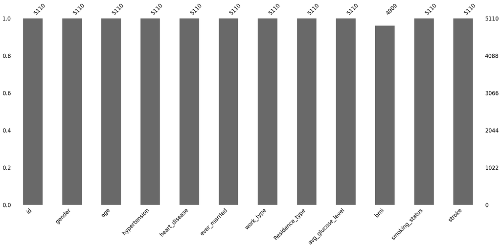

```python
import missingno as msno
msno.bar(df);
```

```python
mean_bmi=df.bmi.mean()
mean_bmi
```

```
28.893236911794666
```

```python
#Filled missing values in the 'bmi' column with the mean of the column.
df.bmi.fillna(mean_bmi,inplace=True)
```

```python
df.bmi.isnull().sum()
```

```
0
```

```python
df.duplicated().sum()
```

```
0
```

```python
df.dtypes
```

```
id                     int64
gender                object
age                  float64
hypertension           int64
heart_disease          int64
ever_married          object
work_type             object
Residence_type        object
avg_glucose_level    float64
bmi                  float64
smoking_status        object
stroke                 int64
dtype: object
```

```python
#Changed the 'id' column's data type to object
df.id=df.id.astype("object")
```

```python
df.rename(columns={"Residence_type":"residence_type"})
```

|  | id | gender | age | hypertension | heart_disease | ever_married | work_type | residence_type | avg_glucose_level | bmi | smoking_status | stroke |
| --- | --- | --- | --- | --- | --- | --- | --- | --- | --- | --- | --- | --- |
| 0 | 9046 | Male | 67.0 | 0 | 1 | Yes | Private | Urban | 228.69 | 36.600000 | formerly smoked | 1 |
| 1 | 51676 | Female | 61.0 | 0 | 0 | Yes | Self-employed | Rural | 202.21 | 28.893237 | never smoked | 1 |
| 2 | 31112 | Male | 80.0 | 0 | 1 | Yes | Private | Rural | 105.92 | 32.500000 | never smoked | 1 |
| 3 | 60182 | Female | 49.0 | 0 | 0 | Yes | Private | Urban | 171.23 | 34.400000 | smokes | 1 |
| 4 | 1665 | Female | 79.0 | 1 | 0 | Yes | Self-employed | Rural | 174.12 | 24.000000 | never smoked | 1 |
| ... | ... | ... | ... | ... | ... | ... | ... | ... | ... | ... | ... | ... |
| 5105 | 18234 | Female | 80.0 | 1 | 0 | Yes | Private | Urban | 83.75 | 28.893237 | never smoked | 0 |
| 5106 | 44873 | Female | 81.0 | 0 | 0 | Yes | Self-employed | Urban | 125.20 | 40.000000 | never smoked | 0 |
| 5107 | 19723 | Female | 35.0 | 0 | 0 | Yes | Self-employed | Rural | 82.99 | 30.600000 | never smoked | 0 |
| 5108 | 37544 | Male | 51.0 | 0 | 0 | Yes | Private | Rural | 166.29 | 25.600000 | formerly smoked | 0 |
| 5109 | 44679 | Female | 44.0 | 0 | 0 | Yes | Govt_job | Urban | 85.28 | 26.200000 | Unknown | 0 |

5110 rows × 12 columns

```python
#Let's analyze how age influences stroke occurrence by grouping data by 'stroke'.
age_df=df.groupby("stroke")[["age"]].agg(Sum=("age",np.sum),
                                  Mean=("age",np.mean),
                                  Max=("age",np.max),
                                  Min=("age",np.min))
age_df
```

| stroke | Sum | Mean | Max | Min |
| --- | --- | --- | --- | --- |
| 0 | 204023.68 | 41.971545 | 82.0 | 0.08 |
| 1 | 16864.32 | 67.728193 | 82.0 | 1.32 |

```python
age_df=age_df.reset_index(drop=False)
age_df
```

|  | stroke | Sum | Mean | Max | Min |
| --- | --- | --- | --- | --- | --- |
| 0 | 0 | 204023.68 | 41.971545 | 82.0 | 0.08 |
| 1 | 1 | 16864.32 | 67.728193 | 82.0 | 1.32 |

```python
sns.set_style("darkgrid")
```

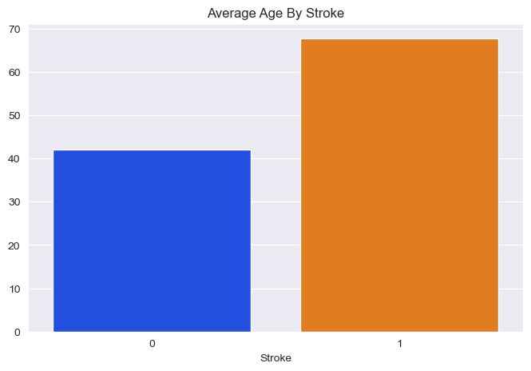

```python
plt.figure(figsize=(8,5))
sns.barplot(x=age_df.stroke,y=age_df.Mean,palette="bright")

plt.title("Average Age By Stroke")
plt.xlabel("Stroke")
plt.ylabel("")
plt.show()
```

```python
def age_group(age):
    if age < 18:
        return "Child"
    elif 18 <= age < 65:
        return "Adult"
    else:
        return "Old"

df['age_group'] = df['age'].apply(age_group)
```

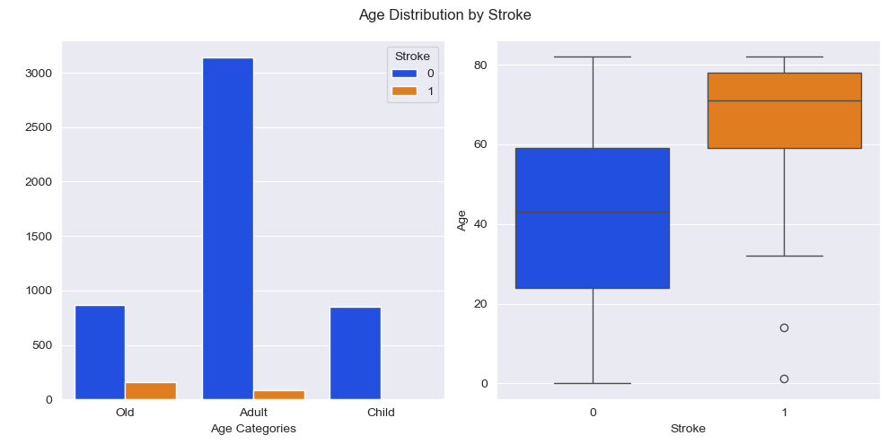

```python
plt.figure(figsize=(10,5))

plt.suptitle("Age Distribution by Stroke")

plt.subplot(1,2,1)
sns.countplot(data=df, x='age_group', hue='stroke', palette="bright")
plt.xlabel('Age Categories')
plt.ylabel(' ')
plt.legend(title='Stroke')

plt.subplot(1,2,2)
sns.boxplot(x=df.stroke,y=df.age,palette="bright")
plt.xlabel("Stroke")
plt.ylabel("Age")

plt.tight_layout()
plt.show()
```

```python
#Explore the relationship between BMI and average glucose level by calculating their correlation
correlation=df["bmi"].corr(df["avg_glucose_level"])
correlation
```

```
0.1687513512260399
```

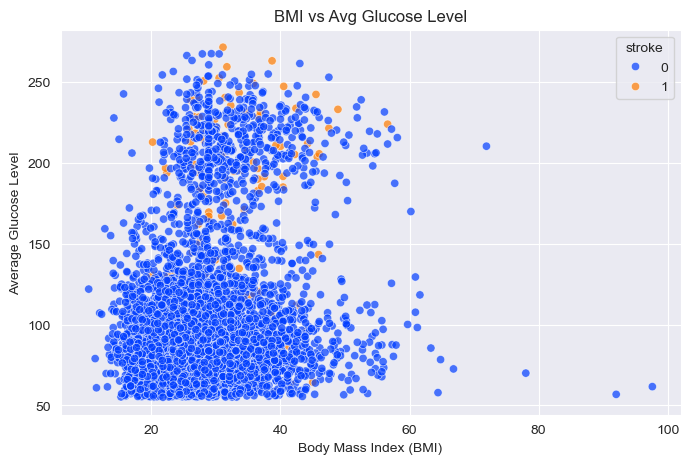

```python
#Visualize the data with a scatter plot, highlighting stroke status for deeper insights.
plt.figure(figsize=(8,5))
sns.scatterplot(data=df, x="bmi", y="avg_glucose_level",hue="stroke" ,alpha=0.7,palette="bright")
plt.title("BMI vs Avg Glucose Level")
plt.xlabel("Body Mass Index (BMI)")
plt.ylabel("Average Glucose Level")
plt.show()
```

•From this analysis, we understand that BMI and average glucose levels are mostly independent, as their correlation is quite low (0.1687). However, we observe more stroke cases at higher glucose levels and BMI values, suggesting that these two factors may contribute to stroke risk separately.

```python
#Analyzed the relationship between smoking status and stroke occurrence.
pd.crosstab(df['smoking_status'], df['stroke'], normalize='index') * 100
```

| stroke smoking_status | 0 | 1 |
| --- | --- | --- |
| Unknown | 96.955959 | 3.044041 |
| formerly smoked | 92.090395 | 7.909605 |
| never smoked | 95.243129 | 4.756871 |
| smokes | 94.676806 | 5.323194 |

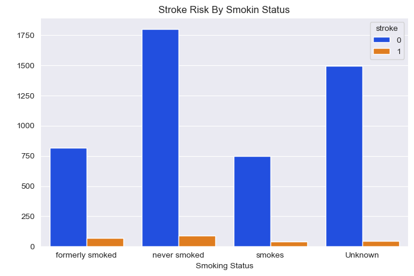

```python
plt.figure(figsize=(8,5))
sns.countplot(x=df['smoking_status'],hue=df['stroke'],palette="bright")
plt.title("Stroke Risk By Smokin Status")
plt.xlabel("Smoking Status")
plt.ylabel(" ")
plt.show()
```

•This analysis shows that individuals who formerly smoked have the highest percentage of stroke cases (7.91%), followed by those who currently smoke (5.32%). Non-smokers and those with unknown smoking status have lower percentages of strokes. This suggests that smoking, particularly in the past, may contribute to a higher stroke risk.

```python
#Investigated whether individuals with heart disease are more likely to experience a stroke by calculating normalized percentages
pd.crosstab(df['heart_disease'], df['stroke'], normalize='index') * 100
```

| stroke heart_disease | 0 | 1 |
| --- | --- | --- |
| 0 | 95.821266 | 4.178734 |
| 1 | 82.971014 | 17.028986 |

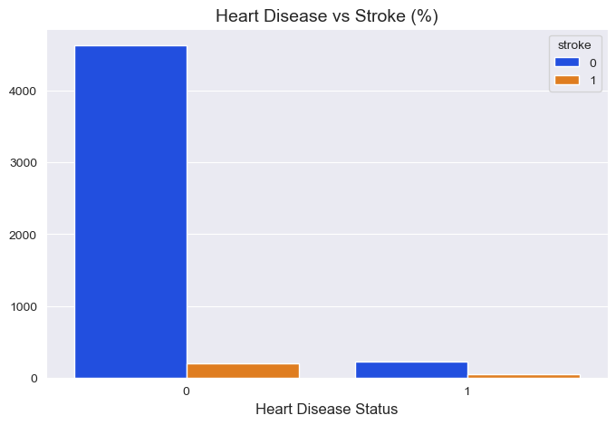

```python
plt.figure(figsize=(8,5))
sns.countplot(x=df['heart_disease'], hue=df['stroke'], palette="bright")


plt.title('Heart Disease vs Stroke (%)', fontsize=14)
plt.xlabel('Heart Disease Status', fontsize=12)
plt.ylabel("")

plt.xticks(fontsize=10)
plt.yticks(fontsize=10)
plt.show()
```

•Individuals with heart disease are observed to have a much higher stroke rate (17.03%) compared to those without heart disease (4.18%). This highlights heart disease as a major risk factor for strokes.

```python
#Let's explore the relationship between work type, hypertension, and stroke by summarizing the data for each work category.
work_df=df.groupby("work_type")[["hypertension","stroke"]].sum().reset_index(drop=False)
work_df
```

|  | work_type | hypertension | stroke |
| --- | --- | --- | --- |
| 0 | Govt_job | 73 | 33 |
| 1 | Never_worked | 0 | 0 |
| 2 | Private | 281 | 149 |
| 3 | Self-employed | 144 | 65 |
| 4 | children | 0 | 2 |

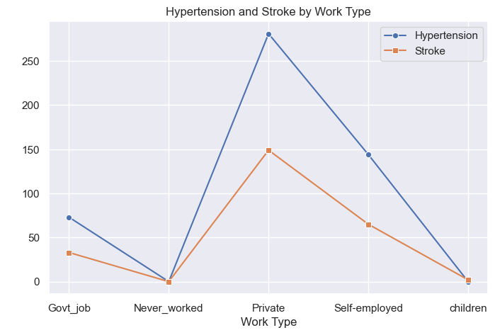

```python
sns.set_theme(style="darkgrid")
plt.figure(figsize=(8,5))

sns.lineplot(data=work_df, x='work_type', y='hypertension', marker='o', label='Hypertension')
sns.lineplot(data=work_df, x='work_type', y='stroke', marker='s', label='Stroke')

plt.legend()
plt.xlabel('Work Type')
plt.ylabel(' ')
plt.title('Hypertension and Stroke by Work Type')

plt.show()
```

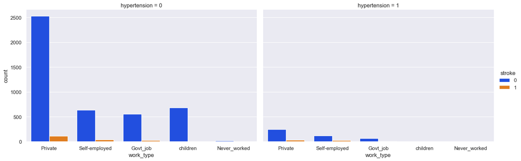

```python
plt.figure(figsize=(10,6))
sns.catplot(
    data=df,
    x="work_type",
    hue="stroke",
    col="hypertension",
    kind="count",
    height=5,
    aspect=1.5,
    palette="bright"
)
plt.show()
```

•The data suggests that individuals in private jobs have the highest number of hypertension (281) and stroke cases (149), followed by self-employed individuals. This indicates that work-related stress could play a role in both hypertension and stroke risk.

```python
#Are males at higher risk of strokes due to work-related or lifestyle stress?
df.groupby("gender")[["stroke"]].sum()
```

| gender | stroke |
| --- | --- |
| Female | 141 |
| Male | 108 |
| Other | 0 |

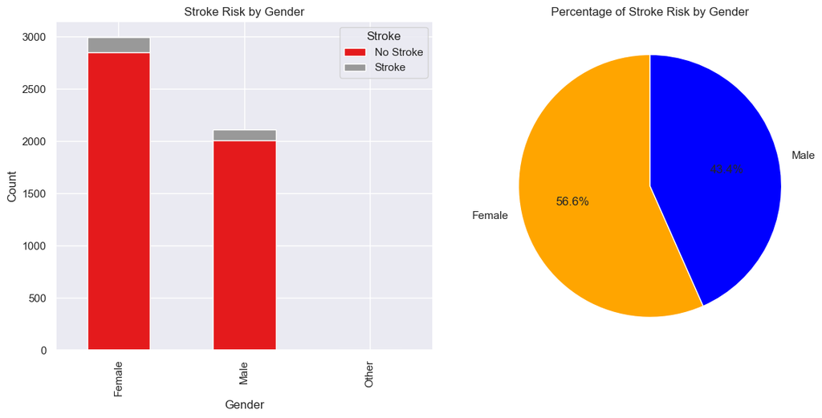

```python
stroke_counts = df.groupby(['gender', 'stroke']).size().unstack(fill_value=0)

fig, axes = plt.subplots(1, 2, figsize=(12, 6))

stroke_counts.plot(
    kind='bar',
    stacked=True,
    colormap='Set1',
    ax=axes[0]
)
axes[0].set_title('Stroke Risk by Gender')
axes[0].set_xlabel('Gender')
axes[0].set_ylabel('Count')
axes[0].legend(title='Stroke', labels=['No Stroke', 'Stroke'])


total_stroke = df[df['stroke'] == 1]['gender'].value_counts()
total_stroke.plot(
    kind='pie',
    autopct='%1.1f%%',
    startangle=90,
    colors=['orange', 'blue'],
    ax=axes[1]
)
axes[1].set_title('Percentage of Stroke Risk by Gender')
axes[1].set_ylabel('')


plt.tight_layout()
plt.show()
```

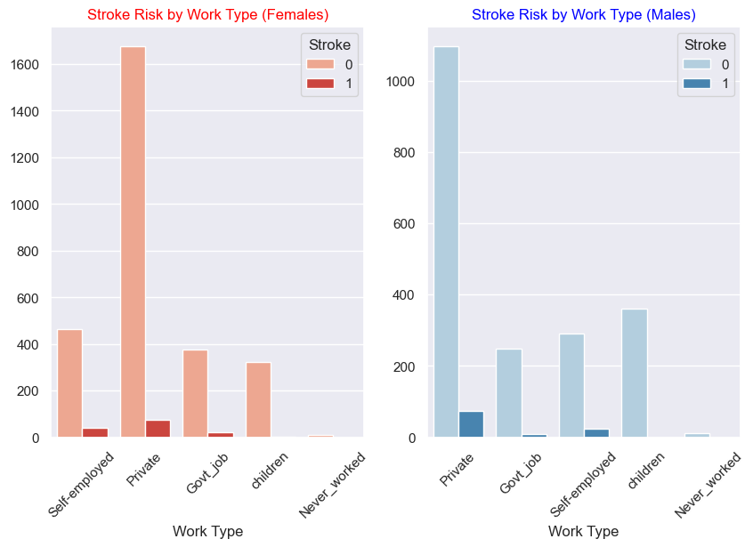

```python
plt.figure(figsize=(10,6))
plt.subplot(1,2,1)

female_df = df[df['gender'] == 'Female']
sns.countplot(data=female_df, x='work_type', hue='stroke',palette="Reds")
plt.title('Stroke Risk by Work Type (Females)',color="red")
plt.xlabel('Work Type')
plt.ylabel('')
plt.legend(title='Stroke')
plt.xticks(rotation=45)

plt.subplot(1,2,2)
male_df = df[df['gender'] == 'Male']
sns.countplot(data=male_df, x='work_type', hue='stroke',palette="Blues")
plt.title('Stroke Risk by Work Type (Males)',color="blue")
plt.xlabel('Work Type')
plt.ylabel('')
plt.legend(title='Stroke')
plt.xticks(rotation=45)
plt.show()
```

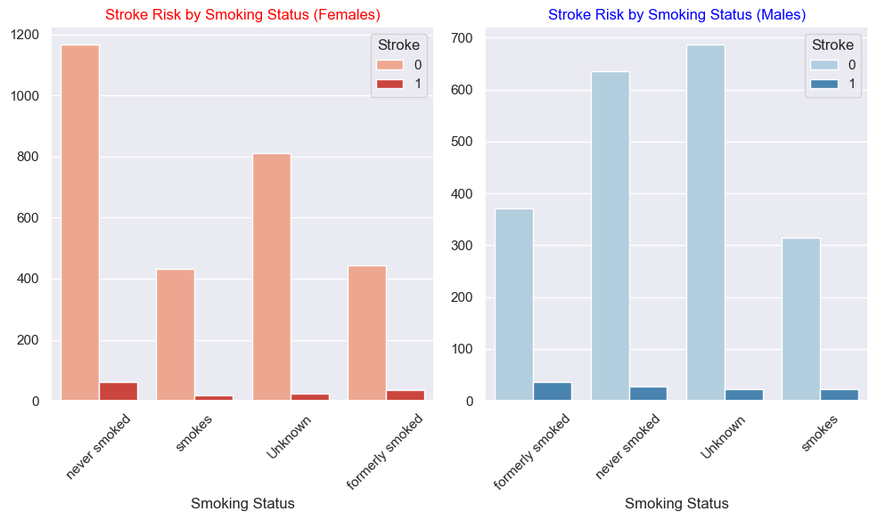

```python
fig, axes=plt.subplots(1,2,figsize=(10,6))

sns.countplot(data=female_df, x='smoking_status', hue='stroke',ax=axes[0],palette="Reds")
axes[0].set_title('Stroke Risk by Smoking Status (Females)',color="red")
axes[0].set_xlabel('Smoking Status')
axes[0].set_ylabel('')
axes[0].legend(title='Stroke')
axes[0].set_xticklabels(axes[0].get_xticklabels(), rotation=45)

sns.countplot(data=male_df, x='smoking_status', hue='stroke',ax=axes[1],palette="Blues")
axes[1].set_title('Stroke Risk by Smoking Status (Males)',color="blue")
axes[1].set_xlabel('Smoking Status')
axes[1].set_ylabel('')
axes[1].legend(title='Stroke')
axes[1].set_xticklabels(axes[1].get_xticklabels(), rotation=45)

plt.tight_layout()
plt.show()
```

•To further analyze stroke risks, I visualized the distribution of work type and smoking status separately for males and females. This allows us to compare how these factors contribute to stroke incidence across genders, providing more detailed insights into potential risk patterns.

```python
#Correlation analysis of risk factors influencing stroke likelihood
corr_map=df.select_dtypes(include=["int","float"]).corr()
corr_map
```

|  | age | hypertension | heart_disease | avg_glucose_level | bmi | stroke |
| --- | --- | --- | --- | --- | --- | --- |
| age | 1.000000 | 0.276398 | 0.263796 | 0.238171 | 0.325942 | 0.245257 |
| hypertension | 0.276398 | 1.000000 | 0.108306 | 0.174474 | 0.160189 | 0.127904 |
| heart_disease | 0.263796 | 0.108306 | 1.000000 | 0.161857 | 0.038899 | 0.134914 |
| avg_glucose_level | 0.238171 | 0.174474 | 0.161857 | 1.000000 | 0.168751 | 0.131945 |
| bmi | 0.325942 | 0.160189 | 0.038899 | 0.168751 | 1.000000 | 0.038947 |
| stroke | 0.245257 | 0.127904 | 0.134914 | 0.131945 | 0.038947 | 1.000000 |

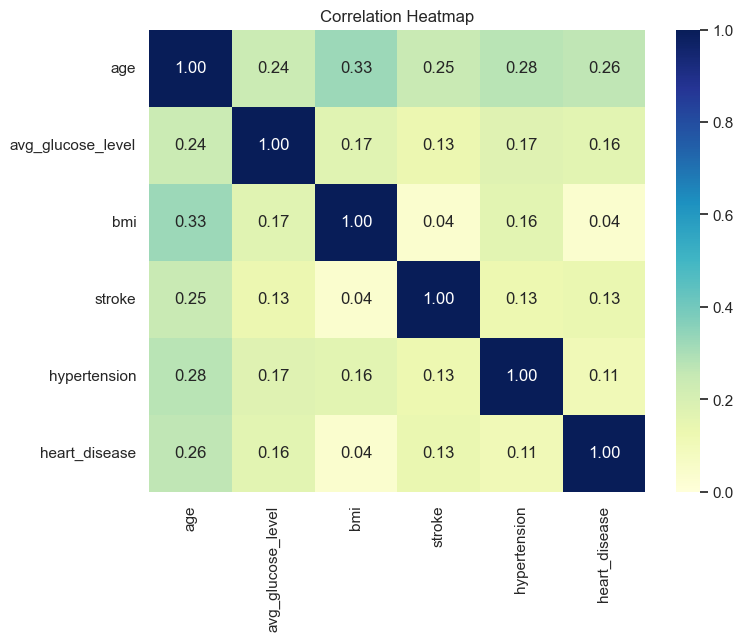

```python
selected_columns = ['age', 'avg_glucose_level', 'bmi', 'stroke', 'hypertension', 'heart_disease']
corr_matrix = df[selected_columns].corr()

plt.figure(figsize=(8, 6))
sns.heatmap(corr_matrix, annot=True, cmap='YlGnBu',vmin=0, vmax=1, fmt='.2f')
plt.title("Correlation Heatmap")
plt.show()
```

```python
hypertension_heartDisease=df[(df["hypertension"]==1) & (df["heart_disease"]==1)]
hypertension_heartDisease
```

|  | id | gender | age | hypertension | heart_disease | ever_married | work_type | Residence_type | avg_glucose_level | bmi | smoking_status | stroke | age_group |
| --- | --- | --- | --- | --- | --- | --- | --- | --- | --- | --- | --- | --- | --- |
| 6 | 53882 | Male | 74.0 | 1 | 1 | Yes | Private | Rural | 70.09 | 27.400000 | never smoked | 1 | Old |
| 35 | 712 | Female | 82.0 | 1 | 1 | No | Private | Rural | 84.03 | 26.500000 | formerly smoked | 1 | Old |
| 115 | 53401 | Male | 71.0 | 1 | 1 | No | Govt_job | Rural | 216.94 | 30.900000 | never smoked | 1 | Old |
| 143 | 37651 | Female | 69.0 | 1 | 1 | No | Self-employed | Urban | 72.17 | 36.800000 | never smoked | 1 | Old |
| 171 | 60739 | Female | 79.0 | 1 | 1 | No | Self-employed | Rural | 60.94 | 28.893237 | never smoked | 1 | Old |
| ... | ... | ... | ... | ... | ... | ... | ... | ... | ... | ... | ... | ... | ... |
| 4590 | 19271 | Female | 82.0 | 1 | 1 | Yes | Self-employed | Urban | 101.56 | 31.500000 | never smoked | 0 | Old |
| 4638 | 72160 | Male | 72.0 | 1 | 1 | Yes | Private | Rural | 60.98 | 34.900000 | formerly smoked | 0 | Old |
| 4684 | 49894 | Female | 78.0 | 1 | 1 | Yes | Private | Rural | 206.53 | 28.893237 | never smoked | 0 | Old |
| 4784 | 70497 | Female | 81.0 | 1 | 1 | Yes | Private | Rural | 126.34 | 27.400000 | smokes | 0 | Old |
| 4855 | 42563 | Female | 57.0 | 1 | 1 | Yes | Private | Rural | 231.72 | 45.700000 | formerly smoked | 0 | Adult |

64 rows × 13 columns

```python
hypertension_heartDisease.stroke.value_counts()
```

```
stroke
0    51
1    13
Name: count, dtype: int64
```

```python
smoking_bmi=df[(df["smoking_status"]=="smokes")& (df["bmi"]>26)]
smoking_bmi
```

|  | id | gender | age | hypertension | heart_disease | ever_married | work_type | Residence_type | avg_glucose_level | bmi | smoking_status | stroke | age_group |
| --- | --- | --- | --- | --- | --- | --- | --- | --- | --- | --- | --- | --- | --- |
| 3 | 60182 | Female | 49.0 | 0 | 0 | Yes | Private | Urban | 171.23 | 34.400000 | smokes | 1 | Adult |
| 11 | 12095 | Female | 61.0 | 0 | 1 | Yes | Govt_job | Rural | 120.46 | 36.800000 | smokes | 1 | Adult |
| 12 | 12175 | Female | 54.0 | 0 | 0 | Yes | Private | Urban | 104.51 | 27.300000 | smokes | 1 | Adult |
| 16 | 56112 | Male | 64.0 | 0 | 1 | Yes | Private | Urban | 191.61 | 37.500000 | smokes | 1 | Adult |
| 28 | 54827 | Male | 69.0 | 0 | 1 | Yes | Self-employed | Urban | 195.23 | 28.300000 | smokes | 1 | Old |
| ... | ... | ... | ... | ... | ... | ... | ... | ... | ... | ... | ... | ... | ... |
| 5072 | 71957 | Female | 35.0 | 0 | 0 | Yes | Private | Rural | 58.72 | 40.000000 | smokes | 0 | Adult |
| 5082 | 24552 | Female | 44.0 | 0 | 0 | Yes | Private | Rural | 72.03 | 37.500000 | smokes | 0 | Adult |
| 5084 | 29540 | Male | 67.0 | 0 | 0 | Yes | Private | Rural | 97.04 | 26.900000 | smokes | 0 | Old |
| 5093 | 32235 | Female | 45.0 | 1 | 0 | Yes | Govt_job | Rural | 95.02 | 28.893237 | smokes | 0 | Adult |
| 5099 | 7293 | Male | 40.0 | 0 | 0 | Yes | Private | Rural | 83.94 | 28.893237 | smokes | 0 | Adult |

578 rows × 13 columns

```python
smoking_bmi.stroke.value_counts()
```

```
stroke
0    544
1     34
Name: count, dtype: int64
```

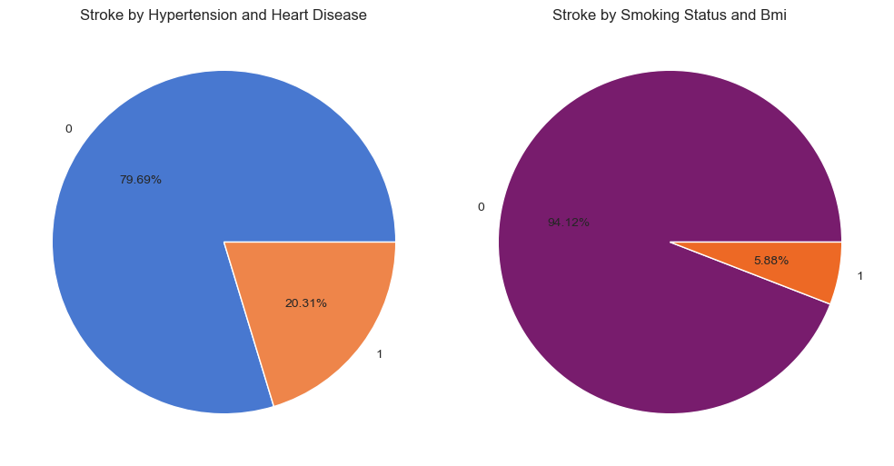

```python
fig, axes=plt.subplots(1,2,figsize=(10,6))

colors = sns.color_palette("muted", 2)
axes[0].pie(hypertension_heartDisease.stroke.value_counts(),labels=hypertension_heartDisease.stroke.value_counts().index,
        autopct="%1.2f%%",
        colors=colors,
        textprops={'fontsize': 10})
axes[0].set_title("Stroke by Hypertension and Heart Disease")

colors = sns.color_palette("inferno", 2)
axes[1].pie(smoking_bmi.stroke.value_counts(),labels=smoking_bmi.stroke.value_counts().index,
        autopct="%1.2f%%",
        colors=colors,
        textprops={'fontsize': 10})
axes[1].set_title("Stroke by Smoking Status and Bmi")

plt.tight_layout()
plt.show()
```

```python
all_factors=df[(df["hypertension"]==1) & (df["heart_disease"]==1)&(df["smoking_status"]=="smokes")& (df["bmi"]>26)]
all_factors.stroke
```

```
184     1
193     1
217     1
218     1
220     1
890     0
1752    0
2433    0
2961    0
3075    0
3436    0
4784    0
Name: stroke, dtype: int64
```

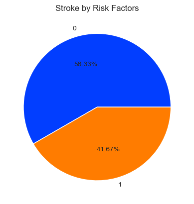

```python
colors = sns.color_palette("bright", 2)
plt.pie(all_factors.stroke.value_counts(),labels=all_factors.stroke.value_counts().index,
        autopct="%1.2f%%",
        colors=colors,
        textprops={'fontsize': 10} )
plt.title("Stroke by Risk Factors")
plt.show()
```

•After identifying key risk factors, such as hypertension, heart disease, smoking status, and high BMI, subsets of the data were created to explore their combined impact on stroke occurrence. By filtering individuals with all these risk factors, the analysis reveals a significant presence of strokes among them, emphasizing the compounded risk from multiple factors.

```python
#Stroke distribution by residence type
df.groupby("Residence_type")[["stroke"]].sum()
```

| Residence_type | stroke |
| --- | --- |
| Rural | 114 |
| Urban | 135 |

```python
df.Residence_type.value_counts()
```

```
Residence_type
Urban    2596
Rural    2514
Name: count, dtype: int64
```

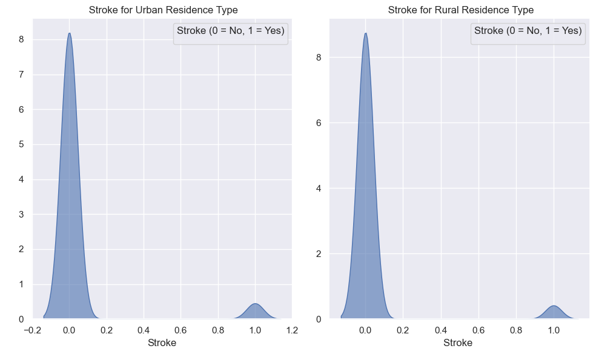

```python
plt.figure(figsize=(10,6))
plt.subplot(1,2,1)

sns.kdeplot(data=df[df["Residence_type"] == "Urban"], x="stroke", fill=True, palette="cool", alpha=0.6)
plt.title(" Stroke for Urban Residence Type")
plt.xlabel("Stroke")
plt.ylabel(" ")
plt.legend(title="Stroke (0 = No, 1 = Yes)")

plt.subplot(1,2,2)

sns.kdeplot(data=df[df["Residence_type"] == "Rural"], x="stroke", fill=True, palette="cool", alpha=0.6)
plt.title(" Stroke for Rural Residence Type")
plt.xlabel("Stroke ")
plt.ylabel(" ")
plt.legend(title="Stroke (0 = No, 1 = Yes)")

plt.tight_layout()
plt.show()
```

•This analyze indicates that residence type might not have a significant impact on stroke occurrence, and other factors could be more influential in determining stroke risk.

```python
#Combine effect of smoking, age and heart disease
age_smoking_heart=df[(df.age>60)&(df.smoking_status=="smokes")&(df.heart_disease==1)].stroke.value_counts()
age_smoking_heart
```

```
stroke
0    29
1    12
Name: count, dtype: int64
```

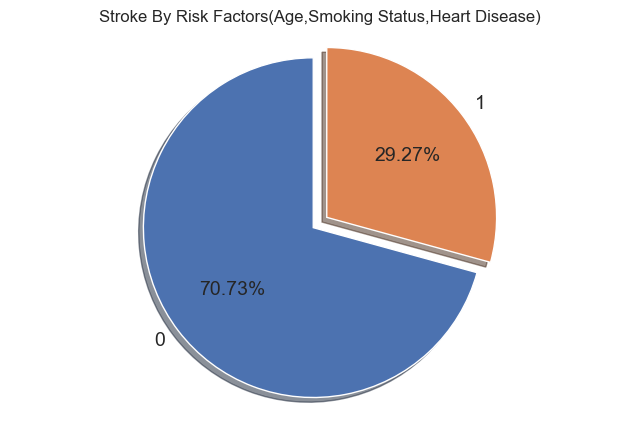

```python
fig, ax = plt.subplots(figsize=(8,5))
ax.pie(age_smoking_heart.values, labels=age_smoking_heart.index, autopct='%1.2f%%', startangle=90,
       explode=(0.1,0), shadow = 0.1, textprops={'fontsize': 14})


ax.set_title('Stroke By Risk Factors(Age,Smoking Status,Heart Disease)')
ax.axis('equal')

plt.show()
```

```python
df[(df.age>60)&(df.heart_disease==1)].stroke.value_counts()
```

```
stroke
0    168
1     42
Name: count, dtype: int64
```

```python
df[(df.age>60)&(df.smoking_status=="smokes")].stroke.value_counts()
```

```
stroke
0    153
1     22
Name: count, dtype: int64
```

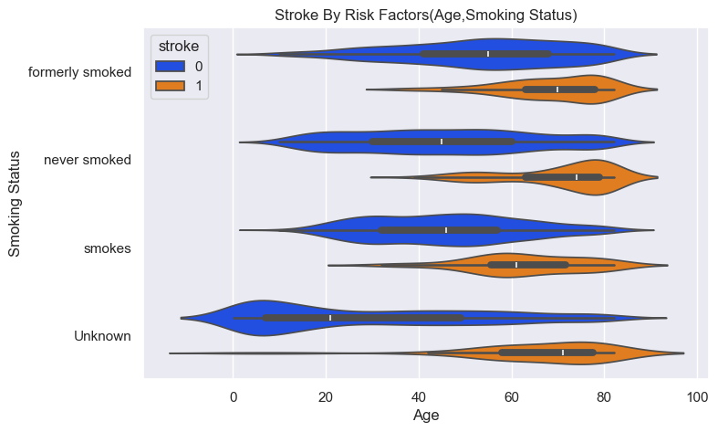

```python
plt.figure(figsize=(8,5))
sns.violinplot(x=df.age,y=df.smoking_status,hue=df.stroke,palette="bright")
plt.title("Stroke By Risk Factors(Age,Smoking Status)")
plt.xlabel("Age")
plt.ylabel("Smoking Status")
plt.show()
```

```python
#Does marital status correlate with stroke likelihood?
pivot=df.pivot_table(values="stroke",index="ever_married")*100
pivot
```

| ever_married | stroke |
| --- | --- |
| No | 1.650541 |
| Yes | 6.561288 |

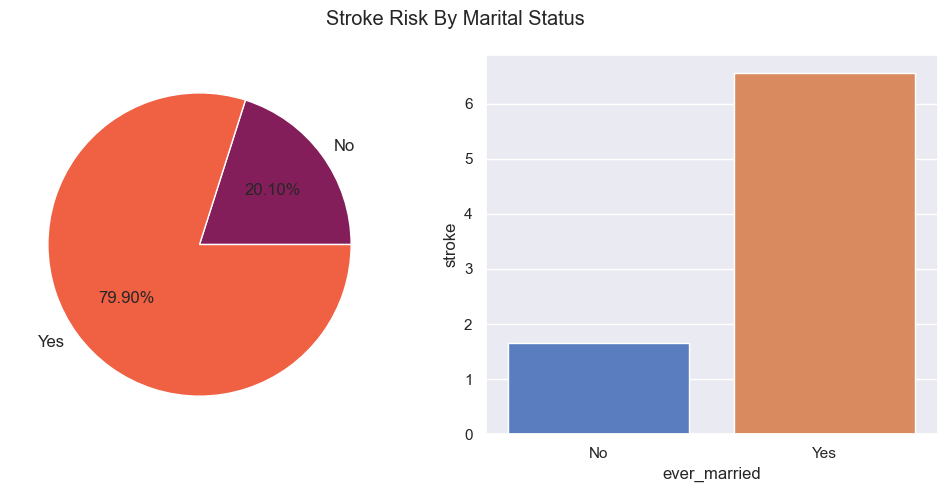

```python
plt.figure(figsize=(10,5))
plt.subplot(1,2,1)

plt.suptitle("Stroke Risk By Marital Status")

colors = sns.color_palette("rocket", 2)
plt.pie(pivot["stroke"],labels=pivot.index,autopct="%1.2f%%",colors=colors,textprops={'fontsize': 12} )

plt.subplot(1,2,2)
sns.barplot(x=pivot.index,y=pivot["stroke"],palette="muted")

plt.tight_layout()
plt.show()
```

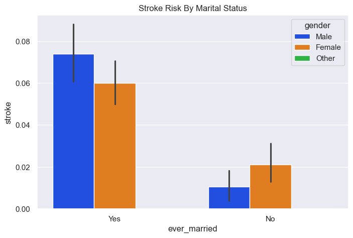

```python
plt.figure(figsize=(8,5))

sns.barplot(x=df.ever_married,y=df.stroke,hue=df.gender,palette="bright")
plt.title("Stroke Risk By Marital Status")
plt.show()
```

•Individuals who are married show a higher stroke rate (6.56%) compared to unmarried individuals (1.65%). This could indicate a potential link between marital status and stroke risk, possibly due to associated lifestyle or health-related factors.

```python
new_pivot=df.pivot_table(index="Residence_type",values="stroke")*100
new_pivot
```

| Residence_type | stroke |
| --- | --- |
| Rural | 4.534606 |
| Urban | 5.200308 |

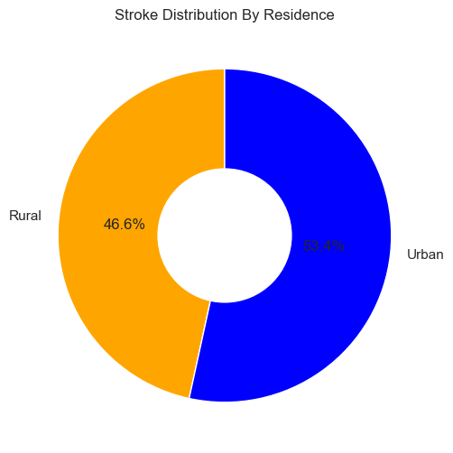

```python
plt.figure(figsize=(8, 6))

colors = ['orange', 'blue']
plt.pie(
    new_pivot["stroke"],
    labels=new_pivot.index,
    autopct='%1.1f%%',
    startangle=90,
    colors=colors,
    wedgeprops={'width': 0.7}
)


plt.gca().add_artist(plt.Circle((0, 0), 0.4, color='white'))

plt.title("Stroke Distribution By Residence")
plt.show()
```

•The percentage of stroke cases is slightly higher in urban areas compared to rural areas. However, this small difference suggests that residence type alone may not have a strong impact on stroke likelihood.

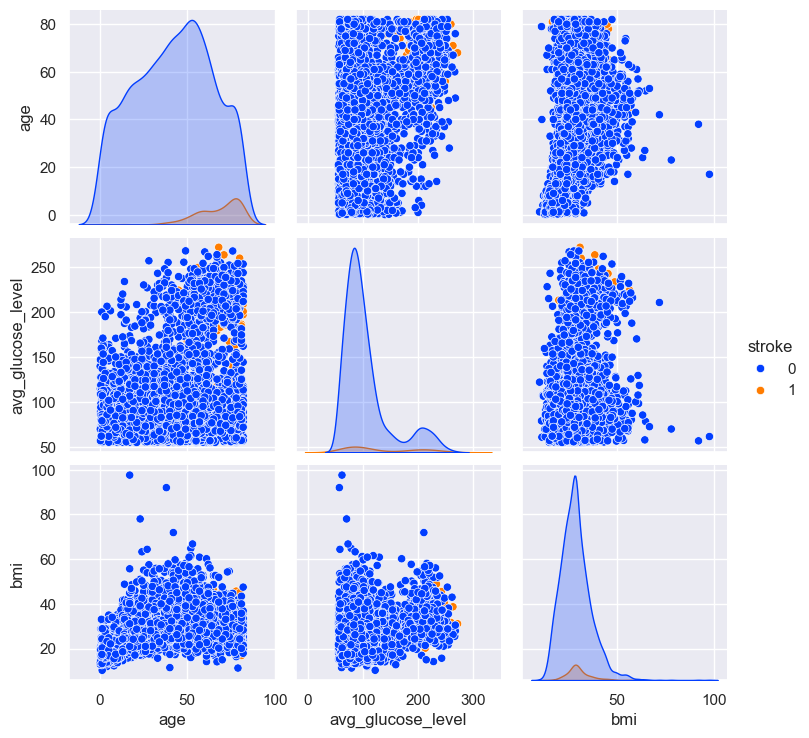

```python
sns.pairplot(df, vars=['age', 'avg_glucose_level', 'bmi'], hue='stroke', palette='bright',diag_kind="kde")
plt.show()
```

•The pair plot highlights the relationships between age, average glucose level, and BMI, categorized by stroke occurrence. Stroke cases are more common at older ages and higher glucose levels, but there seems to be no strong pattern with BMI. This suggests that age and glucose levels may play a more significant role in stroke risk.

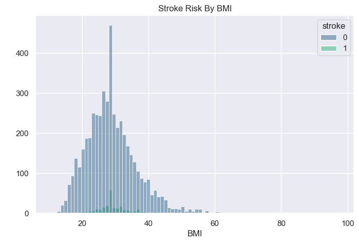

```python
#Stroke risk distribution across BMI
plt.figure(figsize=(8,5))
sns.histplot(x=df.bmi,hue=df.stroke,palette="viridis")
plt.title("Stroke Risk By BMI")
plt.xlabel("BMI")
plt.ylabel(" ")
plt.show()
```

```python
#Categorized BMI values into four groups to better understand the relationship between BMI categories and stroke risk.
#This helps identify if certain BMI ranges are associated with a higher likelihood of stroke.

def categorize_bmi(bmi):
    if bmi < 18.5:
        return "Underweight"
    elif 18.5 <= bmi < 25:
        return "Normal"
    elif 25 <= bmi < 30:
        return "Overweight"
    else:
        return "Obese"

df['bmi_category'] = df['bmi'].apply(categorize_bmi)
```

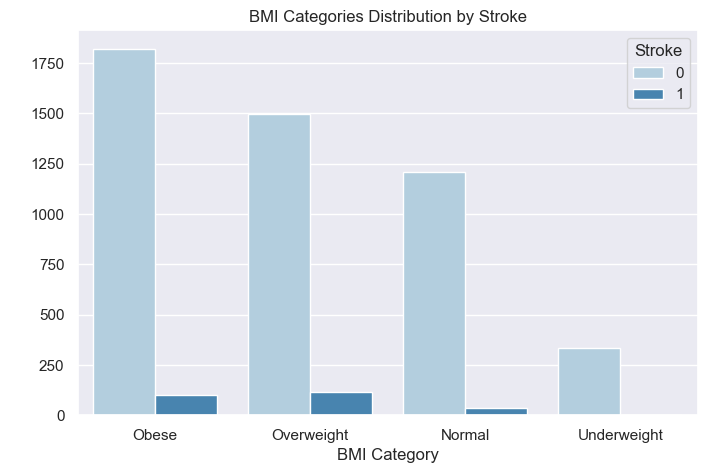

```python
plt.figure(figsize=(8, 5))
sns.countplot(data=df, x='bmi_category', hue='stroke', palette="Blues")
plt.title('BMI Categories Distribution by Stroke')
plt.xlabel('BMI Category')
plt.ylabel(' ')
plt.legend(title='Stroke')
plt.show()
```

•The distribution shows that stroke cases are slightly more prevalent in the 'Obese' and 'Overweight' BMI categories compared to 'Normal' and 'Underweight' groups. However, the difference is not substantial, indicating BMI alone may not be a strong determinant of stroke risk.

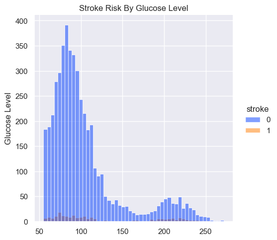

```python
#Stroke risk distribution across glucose levels
plt.figure(figsize=(8,5))

sns.displot(x=df.avg_glucose_level,hue=df.stroke,palette="bright")
plt.title("Stroke Risk By Glucose Level")
plt.xlabel("")
plt.ylabel("Glucose Level")
plt.show()
```

```python
#Divided glucose levels into three categories to analyze their relationship with stroke incidence.
#This categorization helps in identifying if specific glucose ranges are associated with an increased risk of stroke.

def categorize_glucose_level(glucose):
    if glucose < 100:
        return "Low"
    elif 100 <= glucose < 140:
        return "Normal"
    else:
        return "High"

df['glucose_category'] = df['avg_glucose_level'].apply(categorize_glucose_level)
```

```python
df[df['glucose_category']=="High"].stroke.value_counts()
```

```
stroke
0    728
1     93
Name: count, dtype: int64
```

```python
df[df['glucose_category']=="Low"].stroke.value_counts()
```

```
stroke
0    3019
1     112
Name: count, dtype: int64
```

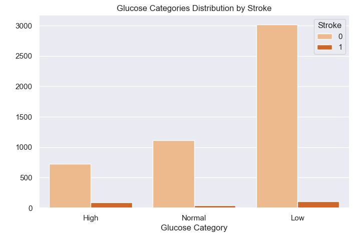

```python
plt.figure(figsize=(8, 5))
sns.countplot(data=df, x='glucose_category', hue='stroke', palette="Oranges")
plt.title('Glucose Categories Distribution by Stroke')
plt.xlabel('Glucose Category')
plt.ylabel(' ')
plt.legend(title='Stroke')
plt.show()
```

CONCLUSION

✔In this notebook, we explored and visualized various factors related to stroke risk using statistical and graphical methods.

✔We categorized and analyzed data based on attributes like age, BMI, glucose levels, and lifestyle factors. By applying techniques such as correlation analysis, pivot tables, and visual comparisons, we gained a deeper understanding of the dataset.

🎉Thank you for joining this journey of exploration and analysis!🎉